# Data Quality Test

Steven Zhang

Dec 6, 2016

## 1 - Synopsis

This is the **first** report of my *Loan Predict Project*, which aims to predict the loan defaults. The original description is on the [Kaggle](https://www.kaggle.com/c/loan-default-prediction).

In this analysis, I will firstly do basic **data quality test** and **primary data selection**.

- test the variability of the training data.
- test the quality of training data.
- test the hidden time-attribute of training data.
- test the distribution of the target data.

Then, in the next analysis, I will do the imputing with caret and mice.

## 2 - Data Processing

### 2.1 - Data Loading

```r
df.train <- read.csv("../dataLoan/train_v2.csv")
dim(df.train)
```

```
## [1] 105471    771
```

From the [data description](https://www.kaggle.com/c/loan-default-prediction/data), the total 771 columns have **1 id column**, **1 target column** and **769 feature columns**.

### 2.2 - Train Data Quality Analysis

#### 2.2.1 - Analysis the Variability

The near-zero-variability columns will be delete. we use a 10000 observations sample in this step.

```r
df.qualities <- df.train[,2:770]
df.sample <- df.qualities[sample(nrow(df.qualities), 10000),]
nsv <- nearZeroVar(df.sample, saveMetrics = TRUE)
near.zero.variance.count <- sum(nsv$nzv)
near.zero.variance.count.names <- rownames(nsv[which(nsv$nzv),])
```

There are totally 15 columns with near zero vaiance, which are f33, f34, f35, f37, f38, f595, f617, f678, f700, f701, f702, f723, f724, f736, f764. They will be remove from the training and testing data.

```r
rm(near.zero.variance.count)
df.qualities <- select(df.qualities, -one_of(near.zero.variance.count.names))
df.sample <- select(df.sample, -one_of(near.zero.variance.count.names))
```

#### 2.2.2 - Analysis the Missing Values

Then I will analysis the missing value of each columns.

```r
df.missing <- apply(df.qualities, 2, function(x) sum(is.na(x)))
df.missing <- df.missing / dim(df.train)[1]
df.missing <- data.frame(y = df.missing)
plot_ly(df.missing, y = ~y, type = "box")
```

[interactive chart not shown]

We can see from the plot above that most columns have missing values, but the largest missing rate is less than 18%. We can handle it with mice or caret in the next analysis. To be simple, caret might be better.

#### 2.2.3 - Analysis the Hidden Time Attribute

The data document gives us an infomation that there was hidden time attribute. We cannot do anything about it, but at least we need to know about the situation.

I will cut the training set into two parts, and use student-test to test the consistency.

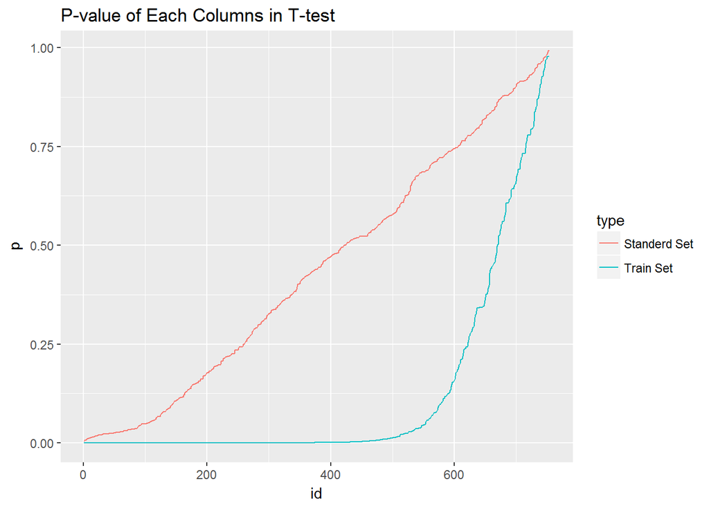

```r
t.test.p.value <- apply(df.qualities, 2, function(x) t.test(x[1:52000], x[52001:105471], var.equal = FALSE, paired = FALSE)$p.value)
temp <- arrange(data.frame(p = t.test.p.value), p)
temp$id <- 1:754
temp$type = "Train Set"
t.test.p.value.standerd <- apply(df.sample, 2, function(x) t.test(x[1:5000], x[5001:10000], var.equal = FALSE, paired = FALSE)$p.value)
temp1 <- arrange(data.frame(p = t.test.p.value.standerd), p)
temp1$id <- 1:754
temp1$type = "Standerd Set"
temp2 <- rbind(temp, temp1)
g <- ggplot(temp2, aes(id, p, col = type))
g <- g + geom_line() + ggtitle("P-value of Each Columns in T-test")
g
```

```r
rm(temp, temp1, temp2, t.test.p.value, t.test.p.value.standerd)
```

We can see a large shift on the p value from the standerd distribution. So we can confirm a obvious time attribute influence.

#### 2.4 - Analysis the Correlation of the Train Set

We need to analysis the Kappa Value to evaluate the correlation of variables. However, it’s based on the correlation matrix, so we need to do the imputing first. I will handle the correlation later.

#### 2.5 - Analysis the Distribution of the Target

According to the data document, the target variable is a integer from 0 to 100.

```r
df.target <- df.train$loss
default.rate <- sum(df.target>0) / length(df.target)
```

The overall default rate is around 9.3%, which is a very unbalanced rate. Then we will see the distribution of the default observation.

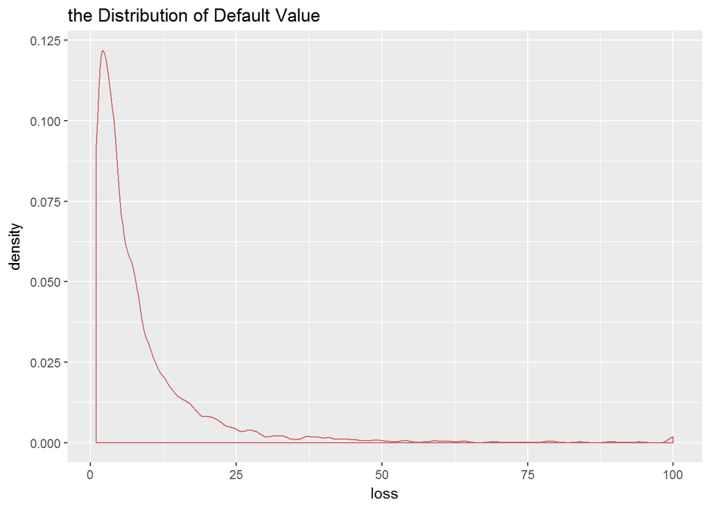

```r
df.target.default <- df.target[df.target > 0]
temp <- data.frame(loss = df.target.default)
g <- ggplot(temp, aes(loss))
g + geom_density(color = "#CC6666") + ggtitle("the Distribution of Default Value")
```

We can see a very unbalanced distribution, which reaches its top at 2. For the data mining after, we need to find a good way to transform it, make it flatter.

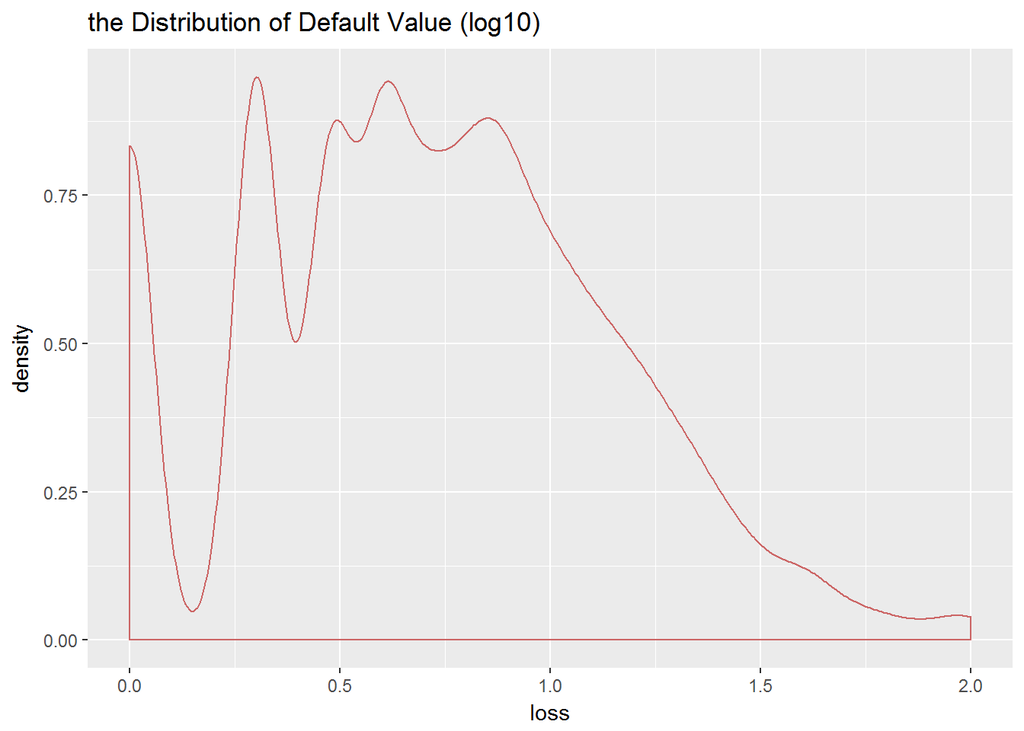

```r
df.target.default <- df.target[df.target > 0]
temp <- data.frame(loss = log10(df.target.default))
g <- ggplot(temp, aes(loss))
g + geom_density(color = "#CC6666") + ggtitle("the Distribution of Default Value (log10)")
```

Now the distribution is much better. We should perform this transform during the Regression.

## 3 - Transforming & Saving

During this step, we only perform one action to the data frame, which remove 15 columns. To be simple, I combine this action to the next step, which makes this report with no output.

## 4 - Summary

### 4.1 - Software & Hardware Env.